# Analysis of $\beta$-diversity, accompanying *Hofstetter et al.*

Matthieu Wilhelm

2024-07-02

We first load and preprocess the data. Note that we also choose the granularity at which we aggregate the data, the object `level.work` in the code below. More precisely, two taxa are considered as different if they belong to a different `level.work` (which can be any of `"order", "family", "genus", "species"`).

```r
source("Load_preprocess_sour_rot.R")
#
library(vegan)

lsSourRot <- LoadSourRot(normalization = FALSE)
dfSourRot <- lsSourRot$dfSourRot
vars <- lsSourRot$vars
types <- lsSourRot$types

rm(lsSourRot)


## selecting the level of accuracy on which we want to work

## possibles arguments are (from coarsest to finest)
# "order", "family", "genus", "species"
level.work <- "species"


dfSourRotDiversity <- dfSourRot[,c(level.work, vars)] |>
  group_by(pick({{level.work}})) |>
  dplyr::summarise(across(.cols = {{vars}}, .fns = ~ sum(.x, na.rm = TRUE)))
```

We then create a data frame where all pairwise $\beta-$diversities are computed (preceded by a standardisation step and using the Bray-Curtis index; see Legendre and De Cáceres (2013)).

$\beta-$diversity can be interpreted as a distance between two different samples. We will group the distances by types and compare them. In plain words, and if consider the analogy of distances, samples can be considered as cities and types as regions or states. If the types are well separated, in which case one may think about regions/types as islands, then the distances between cities (samples) **within** a given region will tend to be smaller than distances between cities that are in different regions. So it is interesting to compare the distribution of the $\beta$-diversity indices with different groups.

```r
df <- dfSourRotDiversity[,-1] |>
  t() |> ### Community data matrix: x with samples as rows and species as column for vegan documentation
  vegan::decostand(method =  "hellinger") |> #### normalization/standardization step
  vegan::vegdist(method = "bray", binary = FALSE) |> #### choice of the beta diversity index.
  as.matrix()
#
#

# Creates a matrix with all combination of two elements among nr elements +
# couples of identical indices, so that indices.unique.types has
# choose(nr, 2) + nr rows
nr <- length(unique(types))
z <- sequence(nr)
indices.unique.types <- cbind(
  row = unlist(lapply(2:nr, function(x) x:nr), use.names = FALSE),
  col = rep(z[-length(z)], times = rev(tail(z, -1))-1))
indices.unique.types <- rbind(indices.unique.types,
                              rep(which(unique(types) == "insect"),2),
                              rep(which(unique(types) == "sour rot"),2),
                              rep(which(unique(types) == "extern"),2))
select.categories <- apply(indices.unique.types, c(2,1),function(z)unique(types)[z]) |> t()
```

Note that the distances are indices that are ranging from 0 (identical samples) to 1 (samples with no overlap at all). We can now create a data frame with all the pairwise distances, together with the couple of categories they belong to. It is then stored in the object `df_plot`, which will then be used for plotting.

```r
df <-  reshape2::melt(data = df, varnames = c("sample_1", "sample_2")) |>
  filter(sample_1 != sample_2) |>
  # distinct() |> # removes the duplicates, as just explained
  left_join(x = _, y = data.frame(samp =vars, type = types), by = c("sample_1" = "samp")) |>
  left_join(x = _, y = data.frame(samp =vars, type = types), by = c("sample_2" = "samp")) |>
  rowwise() |>
  mutate(interaction =factor( paste(type.x, type.y, sep = "-")))
df_plot <- data.frame()
for(i in 1:nrow(select.categories))
{
  df_plot <- rbind(df_plot,
                   df |> filter(type.x == select.categories[i, 1] & type.y == select.categories[i, 2]))
}
```

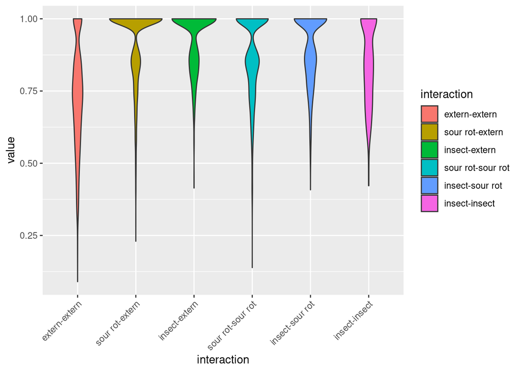

```r
## violin plot
ggplot(df_plot, aes(x = interaction, y  = value, fill  = interaction)) +
  geom_violin()+
  theme(axis.text.x = element_text(angle = 45, vjust = 1, hjust=1))
```

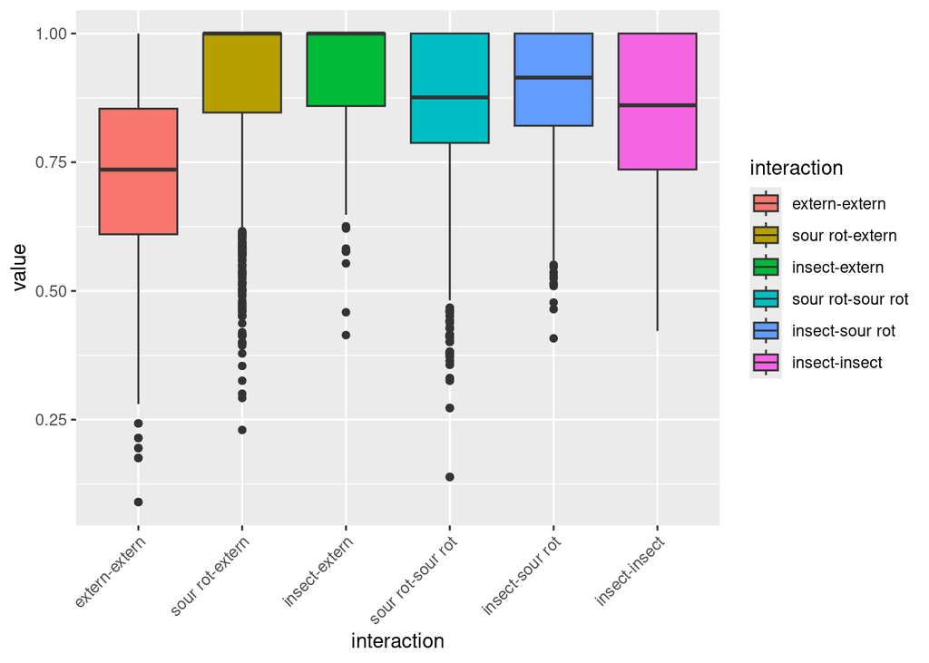

```r
# ggsave("Figures/comparisons_distr_beta_diversity_violin.pdf")

## boxplot
ggplot(df_plot, aes(x = interaction, y  = value, fill  = interaction)) +
  geom_boxplot()+
  theme(axis.text.x = element_text(angle = 45, vjust = 1, hjust=1))
```

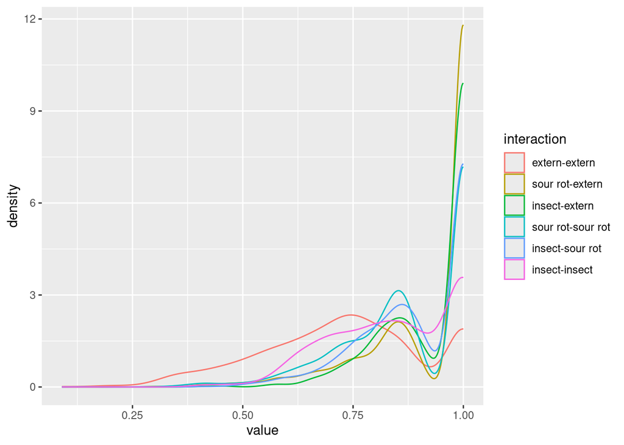

```r
# ggsave("Figures/comparisons_distr_beta_diversity_boxplot.pdf")

## kernel density estimate
ggplot(df_plot, aes(x  = value, col  = interaction)) +
  geom_density()
```

```r
# ggsave("Figures/comparisons_distr_beta_diversity_densities.pdf")
```

#### References

Legendre, P., and M. De Cáceres. 2013. “Beta Diversity as the Variance of Community Data: Dissimilarity Coefficients and Partitioning.” *Ecology Letters* 16 (8): 951–63. https://doi.org/https://doi.org/10.1111/ele.12141.